# Analyses for the paper: Measuring emotions during learning

Franziska Hirt

23 Mai 2019

# 1. PREPARATIONS

```r
# load packages
library(tidyverse)
library(rstan)
library(brms)
library(bayesplot)
library(ggmcmc) # for ggs posterior plot

# set rstan options
rstan::rstan_options(auto_write = TRUE)
options(mc.cores = parallel::detectCores())
```

## Selection of statistical methods

- Bayesian statistics, as they are more intuitive to interpret.
- Mixed models, because events (level 1) are nested within participants (level 2). However, only random intercepts are included for the participants, as additional random effects are hardly identifyable (when only two data rows per participant).
- We did not control for the effect of the specific texts (6 different psychological topics). With only six levels, text does not work as an additional random intercept (level 2 variable). Introducing text as fixed effect (level 1 predictor), however, might be too conservative (the effect of the emotional differences between the texts would be removed).
- Treat emotional self-reports as ordinal outcome variables. Cummulative family in brms, as we understand the Likert-scales as the categorization of a latent continuous construct (Buerkner & Vuorre, 2019: https://journals.sagepub.com/doi/full/10.1177/2515245918823199).
- Assummption of equal variances: “If unequal variances are theoretically possible – and they usually are – we also recommend incorporating them into the model” (Buerkner & Vuorre, 2019). However, models allowing for unequal variances did not converge and were therefore omitted.

### Choosing link function:

link-distributions available for cummulative models in brms (usually only minor impact on results): logit = logistic, probit = gaussian, cloglog = extreme value distribution http://bayesium.com/which-link-function-logit-probit-or-cloglog/

The choice should be made based on some combination of: - Knowledge of the response distribution, - Theoretical considerations, and - Empirical fit to the data. https://stats.stackexchange.com/questions/20523/difference-between-logit-and-probit-models

### interpretation of summary of fitted model

- Estimate is the mean of the posterior distribution, and corresponds to the frequentist point estimate
- Est.Error is the standard deviation of the posterior distribution
- thresholds in ordinal models are called “intercepts” in the output
- Visualisation of marginal effects for ordinal models: https://github.com/paul-buerkner/brms/issues/190

### posterior predictive checks (not included in this document)

for ordinal models pp_check not adequate: https://github.com/stan-dev/bayesplot/issues/73 –> use ppc: https://mc-stan.org/bayesplot/articles/graphical-ppcs.html

## load data

```r
# load data
df <- read_csv("df_TEEM_final.csv")

# rename some variables
df <- df %>% rename("participant" = "subject_nr", "text" = "text_pic", "valence_post" = "SAM_LIKERT_POST")
```

## standardize predictors (aggregated from FaceReader)

(helps for model convergence and for the interpretation of the interaction effects)

```r
df <- df %>%
  mutate(
    mean_interest = scale(mean_interest, center = T, scale = T),
    mean_boredom = scale(mean_boredom, center = T, scale = T),
    mean_valence = scale(mean_valence, center = T), scale = T)

df <- df %>%
  mutate(
    sd_interest = scale(sd_interest, center = T, scale = T),
    sd_boredom = scale(sd_boredom, center = T, scale = T),
    sd_valence = scale(sd_valence, center = T), scale = T)

df <- df %>%
  mutate(
    peak10_interest = scale(peak10_interest, center = T, scale = T),
    peak10_boredom = scale(peak10_boredom, center = T, scale = T),
    peak10_valence_pos = scale(peak10_valence_pos, center = T, scale = T),
    peak10_valence_neg = scale(peak10_valence_neg), center = T, scale = T)
```

# 2. INTEREST

## INTEREST restricted model

```r
# complete cases only (drop NAs)
dfsub <- df %>% select(participant, interested_post, mean_interest, sd_interest, peak10_interest) %>% drop_na()

# restricted model
m0i_cloglog <- brm(
          interested_post ~ 1 + (1|participant),
          family = cumulative("cloglog"),
          prior = prior(cauchy(0, 10), class = sd),
          iter = 4000, warmup = 2000, chains = 4, cores = 4,
          inits = 0,
          data = dfsub,
          save_all_pars = T) # needed for bayes factor later on

summary(m0i_cloglog)
```

```
##  Family: cumulative
##   Links: mu = cloglog; disc = identity
## Formula: interested_post ~ 1 + (1 | participant)
##    Data: dfsub (Number of observations: 205)
## Samples: 4 chains, each with iter = 4000; warmup = 2000; thin = 1;
##          total post-warmup samples = 8000
##
## Group-Level Effects:
## ~participant (Number of levels: 103)
##               Estimate Est.Error l-95% CI u-95% CI Eff.Sample Rhat
## sd(Intercept)     1.19      0.24     0.75     1.70       1755 1.00
##
## Population-Level Effects:
##              Estimate Est.Error l-95% CI u-95% CI Eff.Sample Rhat
## Intercept[1]    -5.09      0.69    -6.62    -3.91       3419 1.00
## Intercept[2]    -2.74      0.31    -3.38    -2.18       4143 1.00
## Intercept[3]    -1.39      0.21    -1.85    -1.01       4483 1.00
## Intercept[4]     0.76      0.19     0.41     1.17       3900 1.00
##
## Samples were drawn using sampling(NUTS). For each parameter, Eff.Sample
## is a crude measure of effective sample size, and Rhat is the potential
## scale reduction factor on split chains (at convergence, Rhat = 1).
```

```r
# other link functions
m0i_logit <-  update(m0i_cloglog,
                    family = cumulative("logit"))

m0i_probit <-  update(m0i_cloglog,
                      family = cumulative("probit"))
# compare different link functions using assimilation of leave-one-out-cross validation (looic)
m0i_logit <- add_criterion(m0i_logit,"loo")
m0i_probit <- add_criterion(m0i_probit,"loo", reloo = TRUE) #"reloo = TRUE" actually calculates MCMC for problematic observations
m0i_cloglog <- add_criterion(m0i_cloglog ,"loo", reloo = TRUE)
print(loo_compare(m0i_logit, m0i_probit, m0i_cloglog, criterion="loo"), simplify = F)  # cloglog 1.5-3.5 SD better
```

```
##             elpd_diff se_diff elpd_loo se_elpd_loo p_loo  se_p_loo looic
## m0i_cloglog    0.0       0.0  -249.1     10.8        61.5    4.5    498.2
## m0i_probit    -1.5       1.4  -250.6     10.4        60.9    4.7    501.3
## m0i_logit     -3.3       1.1  -252.3     10.6        65.5    4.6    504.7
##             se_looic
## m0i_cloglog   21.6
## m0i_probit    20.9
## m0i_logit     21.2
```

```r
# chosen F distribution (link function) for final restricted model
m0i <- m0i_cloglog
```

## INTEREST mean

```r
# full model including FaceReader's estimate as predictor
m1_imean <-  update(m0i, formula. = ~ . + mean_interest,
                    prior = c(prior(normal(0, 10), class = b),
                              prior(cauchy(0, 10), class = sd)),
                    newdata = dfsub,
                    save_all_pars = T,
                    sample_prior = TRUE)

## model parameter
summary(m1_imean)
```

```
##  Family: cumulative
##   Links: mu = cloglog; disc = identity
## Formula: interested_post ~ (1 | participant) + mean_interest
##    Data: dfsub (Number of observations: 205)
## Samples: 4 chains, each with iter = 4000; warmup = 2000; thin = 1;
##          total post-warmup samples = 8000
##
## Group-Level Effects:
## ~participant (Number of levels: 103)
##               Estimate Est.Error l-95% CI u-95% CI Eff.Sample Rhat
## sd(Intercept)     1.16      0.24     0.72     1.64       1512 1.00
##
## Population-Level Effects:
##               Estimate Est.Error l-95% CI u-95% CI Eff.Sample Rhat
## Intercept[1]     -5.17      0.69    -6.70    -4.01       3236 1.00
## Intercept[2]     -2.75      0.30    -3.38    -2.20       3262 1.00
## Intercept[3]     -1.39      0.21    -1.84    -1.01       3846 1.00
## Intercept[4]      0.77      0.19     0.42     1.17       3376 1.00
## mean_interest    -0.27      0.14    -0.54     0.01       5468 1.00
##
## Samples were drawn using sampling(NUTS). For each parameter, Eff.Sample
## is a crude measure of effective sample size, and Rhat is the potential
## scale reduction factor on split chains (at convergence, Rhat = 1).
```

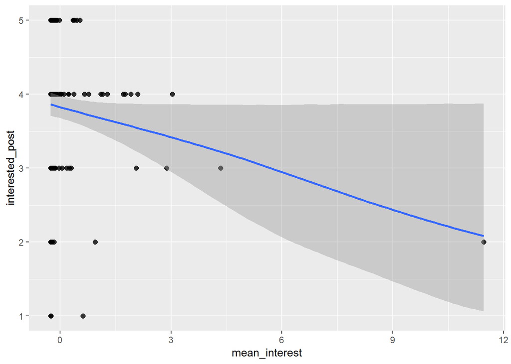

```r
# plots
plot(marginal_effects(m1_imean, "mean_interest", categorical = F), points = T, point_args = c(alpha = 0.8)) # shows the strong influence of two obervations
```

```r
# Model without "outliers"
dfsub_out <- dfsub %>%
  filter(mean_interest < (mean(mean_interest) + 4*sd(mean_interest)) & mean_interest > (mean(mean_interest) - 4*sd(mean_interest)))
# resulting in two observations less
# dfsub %>% filter(mean_interest > (mean(mean_interest) + 4*sd(mean_interest)) | mean_interest < (mean(mean_interest) - 4*sd(mean_interest))) # ouliers are from one participant (highly expressive in video)


m1_imean_out <-  update(m0i, formula. = ~ . + mean_interest,
                    prior = c(prior(normal(0, 10), class = b),
                              prior(cauchy(0, 10), class = sd)),
                    newdata = dfsub_out,
                    save_all_pars = T,
                    sample_prior = TRUE)
summary(m1_imean_out)
```

```
##  Family: cumulative
##   Links: mu = cloglog; disc = identity
## Formula: interested_post ~ (1 | participant) + mean_interest
##    Data: dfsub_out (Number of observations: 203)
## Samples: 4 chains, each with iter = 4000; warmup = 2000; thin = 1;
##          total post-warmup samples = 8000
##
## Group-Level Effects:
## ~participant (Number of levels: 102)
##               Estimate Est.Error l-95% CI u-95% CI Eff.Sample Rhat
## sd(Intercept)     1.18      0.24     0.74     1.68       1631 1.00
##
## Population-Level Effects:
##               Estimate Est.Error l-95% CI u-95% CI Eff.Sample Rhat
## Intercept[1]     -5.04      0.67    -6.51    -3.88       4142 1.00
## Intercept[2]     -2.76      0.31    -3.41    -2.20       3962 1.00
## Intercept[3]     -1.42      0.22    -1.88    -1.03       4531 1.00
## Intercept[4]      0.76      0.19     0.41     1.16       3511 1.00
## mean_interest    -0.17      0.28    -0.72     0.36       4275 1.00
##
## Samples were drawn using sampling(NUTS). For each parameter, Eff.Sample
## is a crude measure of effective sample size, and Rhat is the potential
## scale reduction factor on split chains (at convergence, Rhat = 1).
```

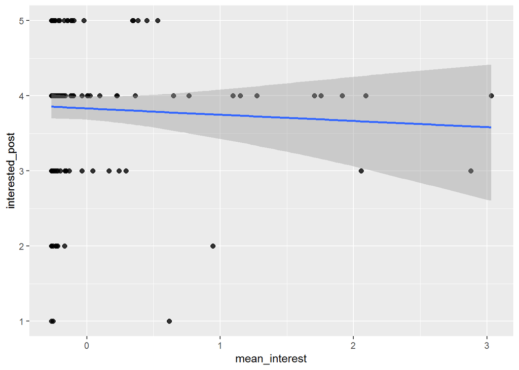

```r
## plots
plot(marginal_effects(m1_imean_out, "mean_interest", categorical = F), points = T, point_args = c(alpha = 0.8))
```

```r
# choose final model
m1_imean <- m1_imean_out
```

## INTEREST mean*SD

```r
# the participant from before also outlier in SD? --> No.
#dfsub_out %>% filter(sd_interest > (mean(sd_interest) + 4*sd(sd_interest)) | sd_interest < (mean(sd_interest) - 4*sd(sd_interest)))


# full model including FaceReader's estimates as predictor
m1_imeanxsd <-  update(m0i, formula. = ~ . + mean_interest*sd_interest,
                    prior = c(prior(normal(0, 10), class = b),
                              prior(cauchy(0, 10), class = sd)),
                    control = list(adapt_delta = 0.99),
                    newdata = dfsub_out, # without outliers of mean interest
                    save_all_pars = T)

## model indicator
summary(m1_imeanxsd)
```

```
##  Family: cumulative
##   Links: mu = cloglog; disc = identity
## Formula: interested_post ~ (1 | participant) + mean_interest + sd_interest + mean_interest:sd_interest
##    Data: dfsub_out (Number of observations: 203)
## Samples: 4 chains, each with iter = 4000; warmup = 2000; thin = 1;
##          total post-warmup samples = 8000
##
## Group-Level Effects:
## ~participant (Number of levels: 102)
##               Estimate Est.Error l-95% CI u-95% CI Eff.Sample Rhat
## sd(Intercept)     1.20      0.25     0.75     1.70       1770 1.00
##
## Population-Level Effects:
##                           Estimate Est.Error l-95% CI u-95% CI Eff.Sample
## Intercept[1]                 -5.10      0.70    -6.63    -3.87       4460
## Intercept[2]                 -2.80      0.35    -3.51    -2.14       4702
## Intercept[3]                 -1.45      0.27    -2.00    -0.93       5234
## Intercept[4]                  0.75      0.27     0.26     1.31       3490
## mean_interest                -0.37      0.97    -2.32     1.52       3989
## sd_interest                   0.22      0.32    -0.43     0.86       4371
## mean_interest:sd_interest    -0.04      0.30    -0.59     0.58       4539
##                           Rhat
## Intercept[1]              1.00
## Intercept[2]              1.00
## Intercept[3]              1.00
## Intercept[4]              1.00
## mean_interest             1.00
## sd_interest               1.00
## mean_interest:sd_interest 1.00
##
## Samples were drawn using sampling(NUTS). For each parameter, Eff.Sample
## is a crude measure of effective sample size, and Rhat is the potential
## scale reduction factor on split chains (at convergence, Rhat = 1).
```

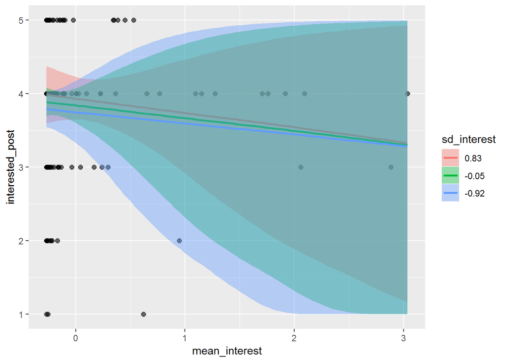

```r
# plots
plot(marginal_effects(m1_imeanxsd,"mean_interest:sd_interest", categorical = F), points = T, point_args = list(alpha = 0.6))
```

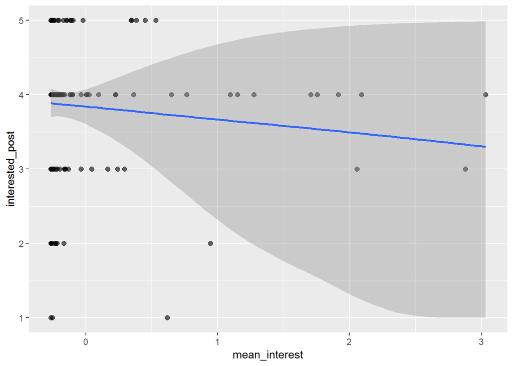

```r
plot(marginal_effects(m1_imeanxsd,"mean_interest", categorical = F), points = T, point_args = list(alpha = 0.6))
```

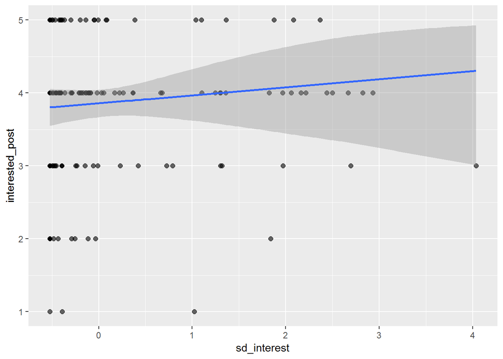

```r
plot(marginal_effects(m1_imeanxsd,"sd_interest", categorical = F), points = T, point_args = list(alpha = 0.6))
```

## INTEREST mean of peaks

```r
# remove outliers from mean also in peak:
dfsub_outpeak <- dfsub %>% filter(peak10_interest < (mean(peak10_interest) + 4*sd(peak10_interest)) & peak10_interest > (mean(peak10_interest) - 4*sd(peak10_interest)))
# dfsub %>% filter(peak10_interest > (mean(peak10_interest) + 4*sd(peak10_interest)) | peak10_interest < (mean(peak10_interest) - 4*sd(peak10_interest)))  # 2 ouliers are from the same participant as before

# model including outliers
m1_ipeak <- update(m0i, formula. = ~ . + peak10_interest,
                    prior = c(prior(normal(0, 10), class = b),
                              prior(cauchy(0, 10), class = sd)),
                              newdata = dfsub,
                              save_all_pars = T)
summary(m1_ipeak)
```

```
##  Family: cumulative
##   Links: mu = cloglog; disc = identity
## Formula: interested_post ~ (1 | participant) + peak10_interest
##    Data: dfsub (Number of observations: 205)
## Samples: 4 chains, each with iter = 4000; warmup = 2000; thin = 1;
##          total post-warmup samples = 8000
##
## Group-Level Effects:
## ~participant (Number of levels: 103)
##               Estimate Est.Error l-95% CI u-95% CI Eff.Sample Rhat
## sd(Intercept)     1.20      0.24     0.74     1.70       1593 1.00
##
## Population-Level Effects:
##                 Estimate Est.Error l-95% CI u-95% CI Eff.Sample Rhat
## Intercept[1]       -5.11      0.68    -6.62    -3.95       3720 1.00
## Intercept[2]       -2.76      0.30    -3.40    -2.21       3640 1.00
## Intercept[3]       -1.41      0.21    -1.86    -1.02       4223 1.00
## Intercept[4]        0.77      0.20     0.42     1.20       2879 1.00
## peak10_interest    -0.21      0.15    -0.51     0.08       3594 1.00
##
## Samples were drawn using sampling(NUTS). For each parameter, Eff.Sample
## is a crude measure of effective sample size, and Rhat is the potential
## scale reduction factor on split chains (at convergence, Rhat = 1).
```

```r
# model without outliers
m1_ipeak_out <- update(m0i, formula. = ~ . + peak10_interest,
                    prior = c(prior(normal(0, 10), class = b),
                              prior(cauchy(0, 10), class = sd)),
                              newdata = dfsub_outpeak,
                              control = list(adapt_delta = 0.99),
                              save_all_pars = T)

## model parameter
summary(m1_ipeak_out)
```

```
##  Family: cumulative
##   Links: mu = cloglog; disc = identity
## Formula: interested_post ~ (1 | participant) + peak10_interest
##    Data: dfsub_outpeak (Number of observations: 203)
## Samples: 4 chains, each with iter = 4000; warmup = 2000; thin = 1;
##          total post-warmup samples = 8000
##
## Group-Level Effects:
## ~participant (Number of levels: 102)
##               Estimate Est.Error l-95% CI u-95% CI Eff.Sample Rhat
## sd(Intercept)     1.19      0.24     0.73     1.68       1564 1.00
##
## Population-Level Effects:
##                 Estimate Est.Error l-95% CI u-95% CI Eff.Sample Rhat
## Intercept[1]       -5.06      0.69    -6.56    -3.88       4199 1.00
## Intercept[2]       -2.77      0.31    -3.40    -2.21       4138 1.00
## Intercept[3]       -1.43      0.22    -1.89    -1.04       4682 1.00
## Intercept[4]        0.75      0.20     0.39     1.17       3166 1.00
## peak10_interest    -0.07      0.19    -0.44     0.33       5043 1.00
##
## Samples were drawn using sampling(NUTS). For each parameter, Eff.Sample
## is a crude measure of effective sample size, and Rhat is the potential
## scale reduction factor on split chains (at convergence, Rhat = 1).
```

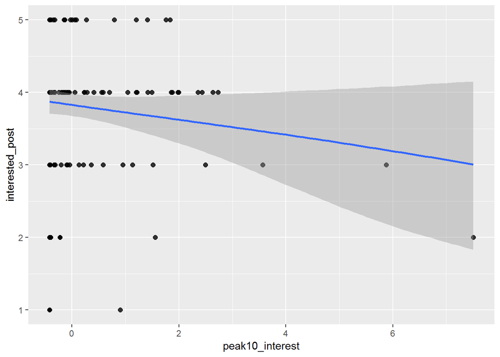

```r
# plots
plot(marginal_effects(m1_ipeak,"peak10_interest", categorical = F), points = T, point_args = c(alpha = 0.8))
```

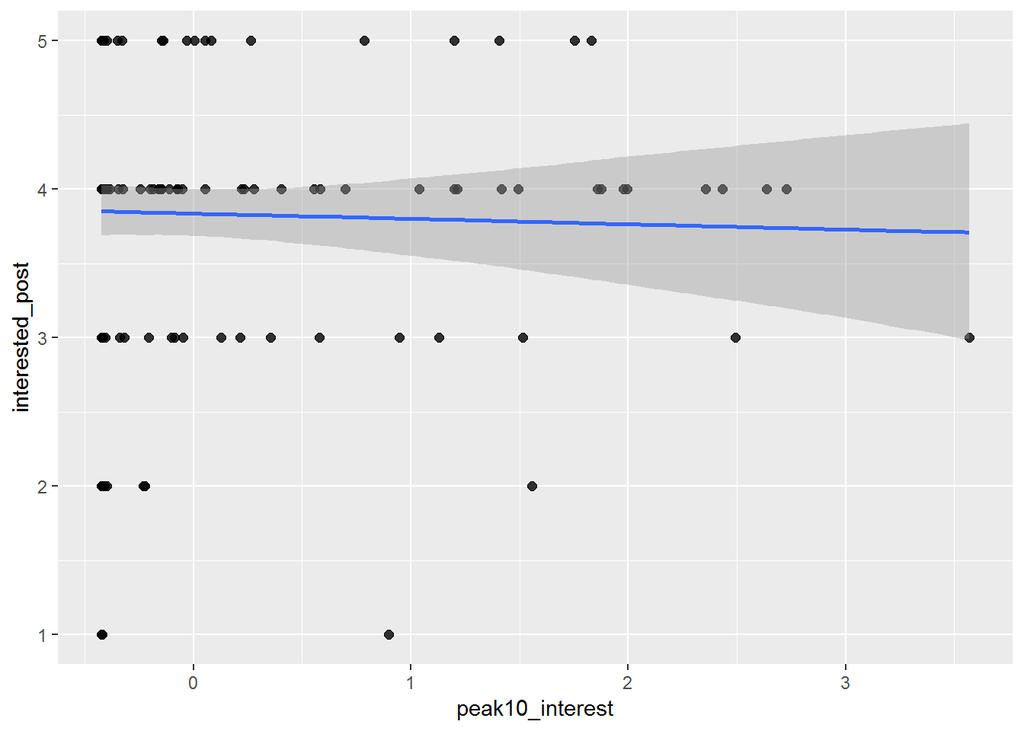

```r
plot(marginal_effects(m1_ipeak_out,"peak10_interest", categorical = F), points = T, point_args = c(alpha = 0.8))
```

```r
# define final model
m1_peak <- m1_ipeak_out
```

# 3. BOREDOM

## BOREDOM restricted model

```r
# complete cases only (drop NAs)
dfsubb <- df %>% select(participant, bored_post, mean_boredom, sd_boredom, peak10_boredom) %>% drop_na()

# restricted model
m0b_cloglog <- brm(
          bored_post ~ 1 + (1|participant),
          family = cumulative("cloglog"),
          prior = prior(cauchy(0, 10), class = sd),
          iter = 4000, warmup = 2000, chains = 4, cores = 4,
          inits = 0,
          data = dfsubb,
          save_all_pars = T)

summary(m0b_cloglog)
```

```
##  Family: cumulative
##   Links: mu = cloglog; disc = identity
## Formula: bored_post ~ 1 + (1 | participant)
##    Data: dfsubb (Number of observations: 204)
## Samples: 4 chains, each with iter = 4000; warmup = 2000; thin = 1;
##          total post-warmup samples = 8000
##
## Group-Level Effects:
## ~participant (Number of levels: 102)
##               Estimate Est.Error l-95% CI u-95% CI Eff.Sample Rhat
## sd(Intercept)     1.32      0.34     0.75     2.05       1183 1.00
##
## Population-Level Effects:
##              Estimate Est.Error l-95% CI u-95% CI Eff.Sample Rhat
## Intercept[1]     0.40      0.21     0.03     0.87       1701 1.00
## Intercept[2]     1.61      0.33     1.06     2.33       1287 1.00
## Intercept[3]     2.68      0.50     1.84     3.78       1420 1.00
## Intercept[4]     3.21      0.65     2.15     4.69       1515 1.00
##
## Samples were drawn using sampling(NUTS). For each parameter, Eff.Sample
## is a crude measure of effective sample size, and Rhat is the potential
## scale reduction factor on split chains (at convergence, Rhat = 1).
```

```r
# other link functions
m0b_logit <-  update(m0b_cloglog,
                    family = cumulative("logit"))

m0b_probit <-  update(m0b_cloglog,
                      family = cumulative("probit"))

# compare different link functions
m0b_logit <- add_criterion(m0b_logit,"loo")
m0b_probit <- add_criterion(m0b_probit,"loo")
m0b_cloglog <- add_criterion(m0b_cloglog ,"loo")
print(loo_compare(m0b_logit, m0b_probit, m0b_cloglog, criterion="loo"), simplify = F)
```

```
##             elpd_diff se_diff elpd_loo se_elpd_loo p_loo  se_p_loo looic
## m0b_cloglog    0.0       0.0  -159.6     11.8        47.7    5.0    319.2
## m0b_probit    -9.1       1.9  -168.7     13.2        52.8    5.4    337.5
## m0b_logit    -10.2       2.4  -169.8     13.5        55.4    5.4    339.6
##             se_looic
## m0b_cloglog   23.7
## m0b_probit    26.5
## m0b_logit     26.9
```

```r
# chosen F distribution (link function)
m0b <- m0b_cloglog
```

## BOREDOM mean

```r
# full model including FaceReader's estimate as predictor
m1_bmean <-  update(m0b, formula. = ~ . + mean_boredom,
                    prior = c(prior(normal(0, 10), class = b),
                              prior(cauchy(0, 10), class = sd)),
                    newdata = dfsubb,
                    save_all_pars = T)

## model parameter
summary(m1_bmean)
```

```
##  Family: cumulative
##   Links: mu = cloglog; disc = identity
## Formula: bored_post ~ (1 | participant) + mean_boredom
##    Data: dfsubb (Number of observations: 204)
## Samples: 4 chains, each with iter = 4000; warmup = 2000; thin = 1;
##          total post-warmup samples = 8000
##
## Group-Level Effects:
## ~participant (Number of levels: 102)
##               Estimate Est.Error l-95% CI u-95% CI Eff.Sample Rhat
## sd(Intercept)     1.40      0.35     0.80     2.17       1206 1.00
##
## Population-Level Effects:
##              Estimate Est.Error l-95% CI u-95% CI Eff.Sample Rhat
## Intercept[1]     0.42      0.22     0.03     0.90       2281 1.00
## Intercept[2]     1.67      0.33     1.11     2.39       1477 1.00
## Intercept[3]     2.77      0.51     1.89     3.90       1469 1.00
## Intercept[4]     3.32      0.64     2.22     4.72       1522 1.00
## mean_boredom    -0.09      0.18    -0.46     0.24       3200 1.00
##
## Samples were drawn using sampling(NUTS). For each parameter, Eff.Sample
## is a crude measure of effective sample size, and Rhat is the potential
## scale reduction factor on split chains (at convergence, Rhat = 1).
```

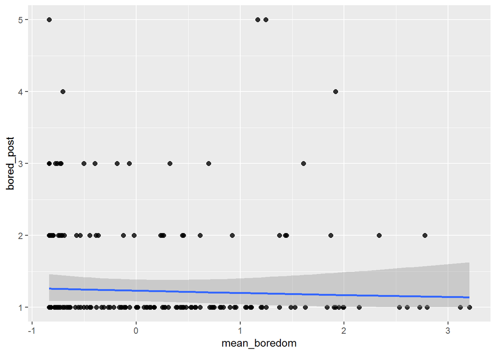

```r
# plots
plot(marginal_effects(m1_bmean, "mean_boredom", categorical = F), points = T, point_args = c(alpha = 0.8))
```

## BOREDOM mean*SD

```r
# full model including FaceReader's estimates as predictor
m1_bmeanxsd <-  update(m0b, formula. = ~ . + mean_boredom*sd_boredom,
                    prior = c(prior(normal(0, 10), class = b),
                              prior(cauchy(0, 10), class = sd)),
                    newdata = dfsubb,
                    save_all_pars = T)

## model indicators
summary(m1_bmeanxsd)
```

```
##  Family: cumulative
##   Links: mu = cloglog; disc = identity
## Formula: bored_post ~ (1 | participant) + mean_boredom + sd_boredom + mean_boredom:sd_boredom
##    Data: dfsubb (Number of observations: 204)
## Samples: 4 chains, each with iter = 4000; warmup = 2000; thin = 1;
##          total post-warmup samples = 8000
##
## Group-Level Effects:
## ~participant (Number of levels: 102)
##               Estimate Est.Error l-95% CI u-95% CI Eff.Sample Rhat
## sd(Intercept)     1.58      0.39     0.93     2.44       1442 1.00
##
## Population-Level Effects:
##                         Estimate Est.Error l-95% CI u-95% CI Eff.Sample
## Intercept[1]                0.77      0.34     0.19     1.53       2461
## Intercept[2]                2.10      0.45     1.34     3.11       1973
## Intercept[3]                3.29      0.63     2.22     4.71       1942
## Intercept[4]                3.91      0.79     2.61     5.72       2034
## mean_boredom               -0.24      0.34    -0.96     0.36       3174
## sd_boredom                 -0.04      0.30    -0.60     0.56       3719
## mean_boredom:sd_boredom     0.37      0.24    -0.04     0.89       3658
##                         Rhat
## Intercept[1]            1.00
## Intercept[2]            1.00
## Intercept[3]            1.00
## Intercept[4]            1.00
## mean_boredom            1.00
## sd_boredom              1.00
## mean_boredom:sd_boredom 1.00
##
## Samples were drawn using sampling(NUTS). For each parameter, Eff.Sample
## is a crude measure of effective sample size, and Rhat is the potential
## scale reduction factor on split chains (at convergence, Rhat = 1).
```

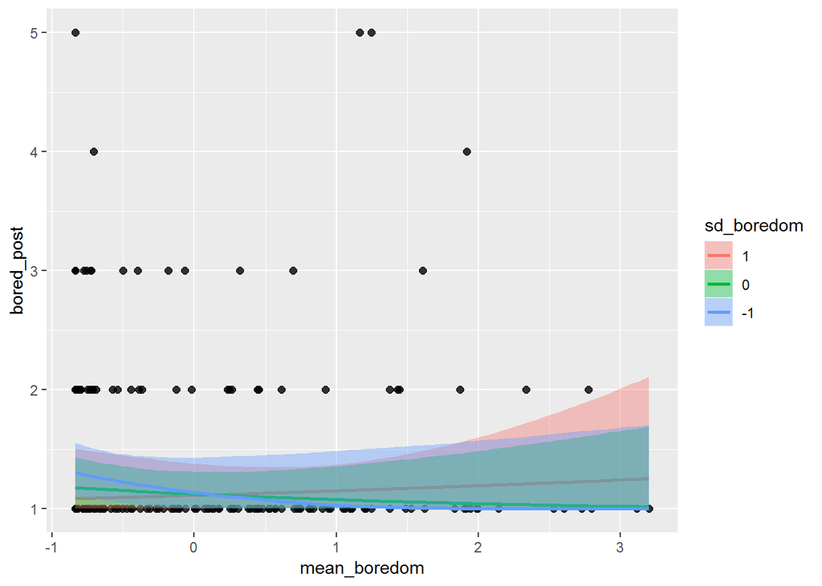

```r
# plots
plot(marginal_effects(m1_bmeanxsd,"mean_boredom:sd_boredom", categorical = F), points = T, point_args = c(alpha = 0.8))
```

```r
## plot densities and CIs of regression coefficient
m1_bmeanxsd_ggs <- ggs(m1_bmeanxsd) # transforms the brms output into a longformat tibble (used to make different types of plots)
m1_bmeanxsd_ggs
```

```
## # A tibble: 3,456,000 x 4
##    Iteration Chain Parameter       value
##        <int> <int> <fct>           <dbl>
##  1         1     1 b_Intercept[1] 0.815
##  2         2     1 b_Intercept[1] 0.815
##  3         3     1 b_Intercept[1] 0.815
##  4         4     1 b_Intercept[1] 0.815
##  5         5     1 b_Intercept[1] 0.0113
##  6         6     1 b_Intercept[1] 0.544
##  7         7     1 b_Intercept[1] 0.541
##  8         8     1 b_Intercept[1] 0.189
##  9         9     1 b_Intercept[1] 0.137
## 10        10     1 b_Intercept[1] 0.317
## # ... with 3,455,990 more rows
```

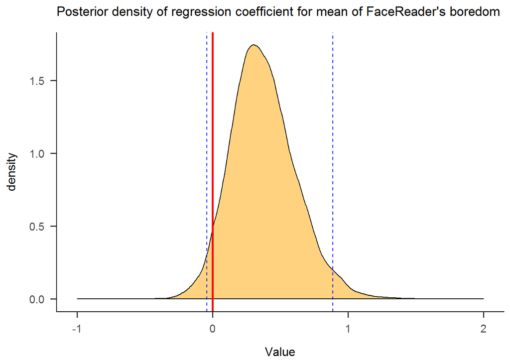

```r
ggplot(filter(m1_bmeanxsd_ggs, Parameter == "b_mean_boredom:sd_boredom", Iteration>1000), aes(x=value)) +
  geom_density(fill = "orange", alpha = .5) + geom_vline(xintercept = 0, col="red", size=1) +
  scale_x_continuous(name="Value", limits=c(-1, 2)) +
  labs(title="Posterior density of regression coefficient for mean of FaceReader's boredom") +
  theme_apa() +
  geom_vline(xintercept = summary(m1_bmeanxsd)$fixed[7,3:4], col="blue", linetype=2) # 95% CrI
```

```r
# 10-fold cross validation
m0b <- add_criterion(m0b, criterion =  "kfold", folds = "grouped", group = "participant")
m1_bmeanxsd <- add_criterion(m1_bmeanxsd, criterion = "kfold", folds = "grouped", group = "participant")
print(loo_compare(m0b, m1_bmeanxsd, criterion = "kfold"), simplify = T) ## Estimating out-of sample predictions (via 10-fold cross validation) of the interaction model, compared to a model with no predictors yielded better results for the model without the interaction. Accordingly, we consider this potential interaction effect as irrelevant.
```

```
##             elpd_diff se_diff
## m0b          0.0       0.0
## m1_bmeanxsd -1.1       2.0
```

## BOREDOM mean of peaks

```r
m1_bpeak <-  update(m0b, formula. = ~ . + peak10_boredom,
                    prior = c(prior(normal(0, 10), class = b),
                              prior(cauchy(0, 10), class = sd)),
                    newdata = dfsubb,
                    save_all_pars = T)

## model parameter
summary(m1_bpeak)
```

```
##  Family: cumulative
##   Links: mu = cloglog; disc = identity
## Formula: bored_post ~ (1 | participant) + peak10_boredom
##    Data: dfsubb (Number of observations: 204)
## Samples: 4 chains, each with iter = 4000; warmup = 2000; thin = 1;
##          total post-warmup samples = 8000
##
## Group-Level Effects:
## ~participant (Number of levels: 102)
##               Estimate Est.Error l-95% CI u-95% CI Eff.Sample Rhat
## sd(Intercept)     1.39      0.35     0.79     2.15       1408 1.00
##
## Population-Level Effects:
##                Estimate Est.Error l-95% CI u-95% CI Eff.Sample Rhat
## Intercept[1]       0.42      0.22     0.04     0.93       1931 1.00
## Intercept[2]       1.67      0.34     1.11     2.43       1555 1.00
## Intercept[3]       2.77      0.52     1.89     3.90       1713 1.00
## Intercept[4]       3.32      0.66     2.23     4.82       1841 1.00
## peak10_boredom    -0.16      0.17    -0.51     0.18       3345 1.00
##
## Samples were drawn using sampling(NUTS). For each parameter, Eff.Sample
## is a crude measure of effective sample size, and Rhat is the potential
## scale reduction factor on split chains (at convergence, Rhat = 1).
```

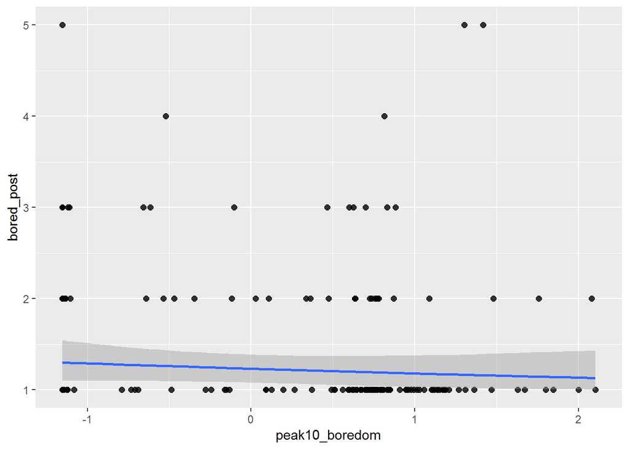

```r
# plots
plot(marginal_effects(m1_bpeak,"peak10_boredom", categorical = F), points = T, point_args = c(alpha = 0.8))
```

# 4. VALENCE

stronger priors for valence, as issues with convergence. ## VALENCE restricted model

```r
## select complete cases of relevant variables
dfsubv <- df %>% select(participant, valence_post, mean_valence, sd_valence, peak10_valence_pos, peak10_valence_neg) %>% drop_na()

# restricted model
## probit-model
m0v_probit <- brm(
          valence_post ~ 1 + (1|participant),
          family = cumulative("probit"),
          prior = c(prior(normal(0, 1), class = Intercept),
                    prior(cauchy(0, 1), class = sd)),
          iter = 4000, warmup = 2000, chains = 4, cores = 4,
          control = list(adapt_delta = 0.99, max_treedepth = 15),
          data = dfsubv,
          inits = 0,
          save_all_pars = T)
summary(m0v_probit)
```

```
##  Family: cumulative
##   Links: mu = probit; disc = identity
## Formula: valence_post ~ 1 + (1 | participant)
##    Data: dfsubv (Number of observations: 193)
## Samples: 4 chains, each with iter = 4000; warmup = 2000; thin = 1;
##          total post-warmup samples = 8000
##
## Group-Level Effects:
## ~participant (Number of levels: 97)
##               Estimate Est.Error l-95% CI u-95% CI Eff.Sample Rhat
## sd(Intercept)     1.27      0.20     0.91     1.68       1692 1.00
##
## Population-Level Effects:
##              Estimate Est.Error l-95% CI u-95% CI Eff.Sample Rhat
## Intercept[1]    -3.32      0.38    -4.16    -2.67       5256 1.00
## Intercept[2]    -3.04      0.30    -3.66    -2.48       6279 1.00
## Intercept[3]    -2.88      0.28    -3.45    -2.36       5817 1.00
## Intercept[4]    -2.60      0.25    -3.12    -2.12       5627 1.00
## Intercept[5]    -1.60      0.20    -2.01    -1.23       5700 1.00
## Intercept[6]    -0.52      0.17    -0.85    -0.20       4867 1.00
## Intercept[7]     0.95      0.20     0.59     1.37       2524 1.00
## Intercept[8]     2.44      0.30     1.88     3.06       2316 1.00
##
## Samples were drawn using sampling(NUTS). For each parameter, Eff.Sample
## is a crude measure of effective sample size, and Rhat is the potential
## scale reduction factor on split chains (at convergence, Rhat = 1).
```

```r
# chosen F distribution (Link function)
m0v <- m0v_probit
```

## VALENCE mean

```r
# full model including FaceReader's estimate as predictor
m1_vmean <-  update(m0v, formula. = ~ . + mean_valence,
                    prior = c(prior(normal(0, 1), class = Intercept),
                              prior(normal(0, 1), class = b),
                              prior(cauchy(0, 1), class = sd)),
                    newdata = dfsubv,
                    save_all_pars = T,
                    sample_prior = T)

## model parameter
summary(m1_vmean)
```

```
##  Family: cumulative
##   Links: mu = probit; disc = identity
## Formula: valence_post ~ (1 | participant) + mean_valence
##    Data: dfsubv (Number of observations: 193)
## Samples: 4 chains, each with iter = 4000; warmup = 2000; thin = 1;
##          total post-warmup samples = 8000
##
## Group-Level Effects:
## ~participant (Number of levels: 97)
##               Estimate Est.Error l-95% CI u-95% CI Eff.Sample Rhat
## sd(Intercept)     1.28      0.20     0.92     1.69       1766 1.00
##
## Population-Level Effects:
##              Estimate Est.Error l-95% CI u-95% CI Eff.Sample Rhat
## Intercept[1]    -3.32      0.39    -4.18    -2.65       5303 1.00
## Intercept[2]    -3.04      0.31    -3.68    -2.48       6597 1.00
## Intercept[3]    -2.89      0.28    -3.47    -2.37       6522 1.00
## Intercept[4]    -2.61      0.26    -3.14    -2.12       6175 1.00
## Intercept[5]    -1.61      0.20    -2.01    -1.24       5508 1.00
## Intercept[6]    -0.53      0.17    -0.85    -0.20       5248 1.00
## Intercept[7]     0.95      0.20     0.59     1.36       3363 1.00
## Intercept[8]     2.44      0.30     1.89     3.07       2706 1.00
## mean_valence    -0.01      0.14    -0.29     0.27       4384 1.00
##
## Samples were drawn using sampling(NUTS). For each parameter, Eff.Sample
## is a crude measure of effective sample size, and Rhat is the potential
## scale reduction factor on split chains (at convergence, Rhat = 1).
```

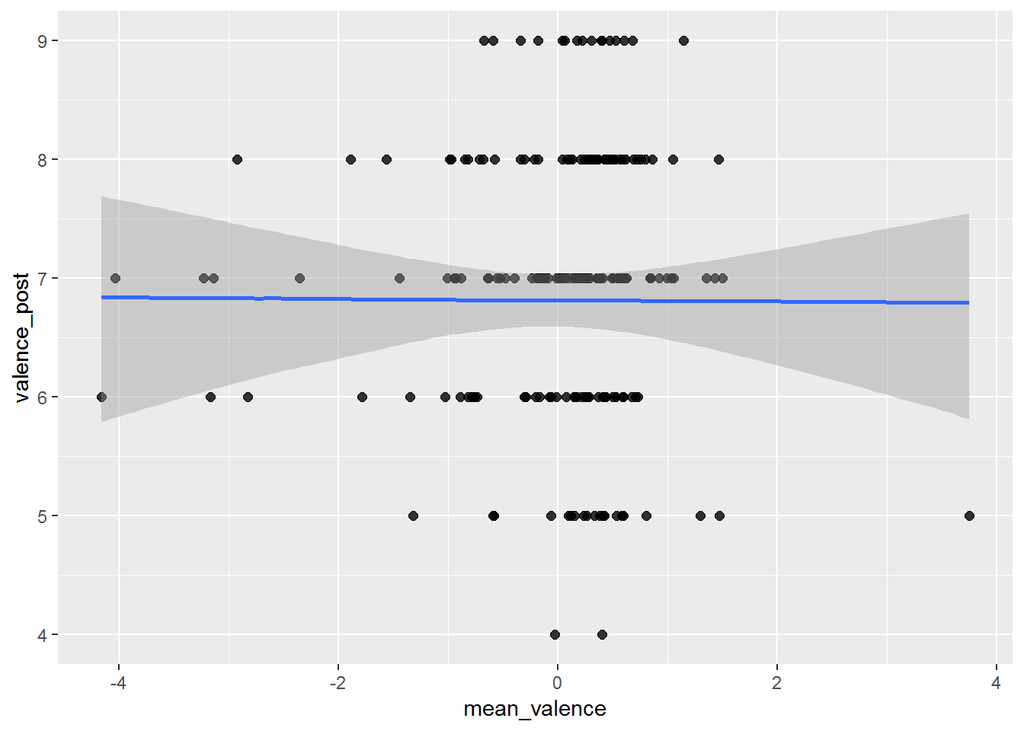

```r
# plots
plot(marginal_effects(m1_vmean, "mean_valence", categorical = F), points = T, point_args = c(alpha = 0.8))
```

## VALENCE mean*SD

```r
# full model including FaceReader's estimates as predictor
m1_vmeanxsd <-  update(m0v, formula. = ~ . + mean_valence*sd_valence,
                    prior = c(prior(normal(0, 1), class = Intercept),
                              prior(normal(0, 1), class = b),
                              prior(cauchy(0, 1), class = sd)),
                    control = list(adapt_delta = 0.99, max_treedepth = 15),
                    newdata = dfsubv,
                    save_all_pars = T,
                    sample_prior = T)

## model parameter
summary(m1_vmeanxsd)
```

```
##  Family: cumulative
##   Links: mu = probit; disc = identity
## Formula: valence_post ~ (1 | participant) + mean_valence + sd_valence + mean_valence:sd_valence
##    Data: dfsubv (Number of observations: 193)
## Samples: 4 chains, each with iter = 4000; warmup = 2000; thin = 1;
##          total post-warmup samples = 8000
##
## Group-Level Effects:
## ~participant (Number of levels: 97)
##               Estimate Est.Error l-95% CI u-95% CI Eff.Sample Rhat
## sd(Intercept)     1.33      0.20     0.96     1.74       1902 1.00
##
## Population-Level Effects:
##                         Estimate Est.Error l-95% CI u-95% CI Eff.Sample
## Intercept[1]               -3.29      0.39    -4.16    -2.61       4693
## Intercept[2]               -3.01      0.31    -3.66    -2.43       6205
## Intercept[3]               -2.86      0.29    -3.44    -2.31       6107
## Intercept[4]               -2.58      0.26    -3.11    -2.09       5558
## Intercept[5]               -1.58      0.20    -1.99    -1.19       4540
## Intercept[6]               -0.48      0.18    -0.82    -0.12       4616
## Intercept[7]                1.03      0.21     0.65     1.48       3108
## Intercept[8]                2.56      0.31     1.97     3.21       2938
## mean_valence                0.16      0.24    -0.31     0.63       3265
## sd_valence                  0.03      0.14    -0.24     0.30       4064
## mean_valence:sd_valence    -0.13      0.15    -0.42     0.15       3696
##                         Rhat
## Intercept[1]            1.00
## Intercept[2]            1.00
## Intercept[3]            1.00
## Intercept[4]            1.00
## Intercept[5]            1.00
## Intercept[6]            1.00
## Intercept[7]            1.00
## Intercept[8]            1.00
## mean_valence            1.00
## sd_valence              1.00
## mean_valence:sd_valence 1.00
##
## Samples were drawn using sampling(NUTS). For each parameter, Eff.Sample
## is a crude measure of effective sample size, and Rhat is the potential
## scale reduction factor on split chains (at convergence, Rhat = 1).
```

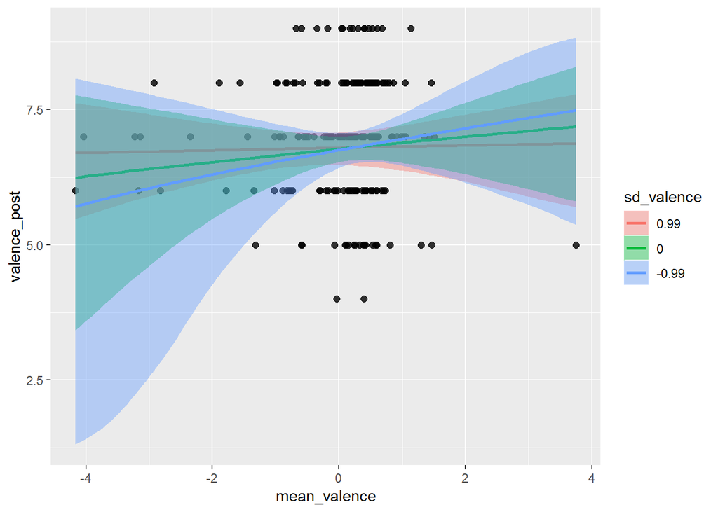

```r
# plots
plot(marginal_effects(m1_vmeanxsd,"mean_valence:sd_valence"), points = T, point_args = c(alpha = 0.8))
```

## VALENCE mean of peaks

```r
m1_vpeak <-  update(m0v, formula. = ~ . + peak10_valence_neg + peak10_valence_pos,
                    prior = c(prior(normal(0, 1), class = Intercept),
                              prior(normal(0, 1), class = b),
                              prior(cauchy(0, 1), class = sd)),
                    newdata = dfsubv,
                    save_all_pars = T)

## model parameter
summary(m1_vpeak)
```

```
##  Family: cumulative
##   Links: mu = probit; disc = identity
## Formula: valence_post ~ (1 | participant) + peak10_valence_neg + peak10_valence_pos
##    Data: dfsubv (Number of observations: 193)
## Samples: 4 chains, each with iter = 4000; warmup = 2000; thin = 1;
##          total post-warmup samples = 8000
##
## Group-Level Effects:
## ~participant (Number of levels: 97)
##               Estimate Est.Error l-95% CI u-95% CI Eff.Sample Rhat
## sd(Intercept)     1.29      0.20     0.93     1.71       1663 1.00
##
## Population-Level Effects:
##                    Estimate Est.Error l-95% CI u-95% CI Eff.Sample Rhat
## Intercept[1]          -3.32      0.39    -4.17    -2.64       5328 1.00
## Intercept[2]          -3.04      0.31    -3.68    -2.47       6324 1.00
## Intercept[3]          -2.89      0.28    -3.46    -2.37       6334 1.00
## Intercept[4]          -2.60      0.25    -3.12    -2.13       5827 1.00
## Intercept[5]          -1.61      0.20    -2.02    -1.23       4962 1.00
## Intercept[6]          -0.52      0.17    -0.86    -0.20       4505 1.00
## Intercept[7]           0.97      0.20     0.60     1.38       2823 1.00
## Intercept[8]           2.47      0.31     1.89     3.10       2542 1.00
## peak10_valence_neg    -0.05      0.14    -0.33     0.23       3532 1.00
## peak10_valence_pos     0.04      0.12    -0.20     0.28       4394 1.00
##
## Samples were drawn using sampling(NUTS). For each parameter, Eff.Sample
## is a crude measure of effective sample size, and Rhat is the potential
## scale reduction factor on split chains (at convergence, Rhat = 1).
```

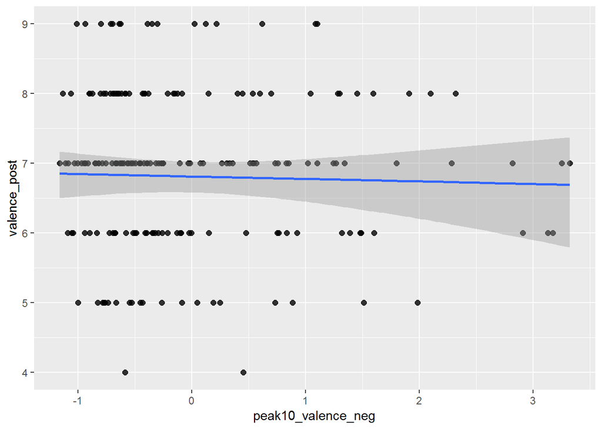

```r
# plots
plot(marginal_effects(m1_vpeak,"peak10_valence_neg", categorical = F), points = T, point_args = c(alpha = 0.8))
```

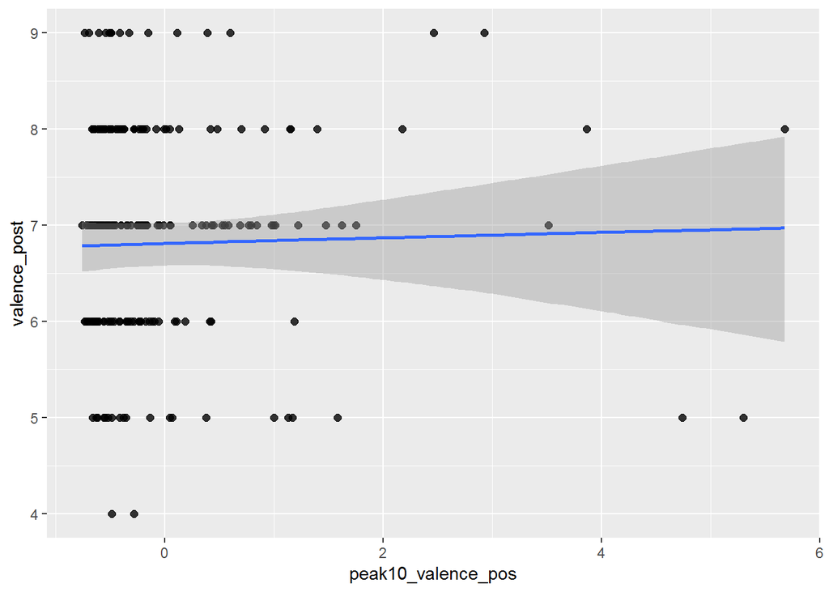

```r
plot(marginal_effects(m1_vpeak,"peak10_valence_pos", categorical = F), points = T, point_args = c(alpha = 0.8))
```